# Unsupervised Recovery of SARS-CoV-2 Variant Structure via Entropy-Driven Site Selection and PAM Clustering: Precision, Recall, and F1 Evaluation Across Wild-Type and Delta-Dominated Surveillance Perio

### 12.0.1 k = 4 (wild-type = cluster 1)

```r
# Apply coordinate filter
region_A <- tsne_base$X[wt_rows] > 15  & tsne_base$Y[wt_rows] <= 0
region_B <- tsne_base$X[wt_rows] > -10 & tsne_base$X[wt_rows] < 10 &
            tsne_base$Y[wt_rows] < -10
is_bl   <- region_A | region_B
bl_rows <- wt_rows[is_bl]

cat(sprintf("%d wt-cluster sequences fall in the boundary t-SNE region(s).\n\n",
            length(bl_rows)))
```

4 wt-cluster sequences fall in the boundary t-SNE region(s).

```r
if (length(bl_rows) == 0L) {
  cat("*No sequences in the defined boundary regions.*\n\n")
} else {

  # t-SNE distances to own and nearest foreign medoid
  wt_med_x <- tsne_base$X[med_rows[wt_cl]]
  wt_med_y <- tsne_base$Y[med_rows[wt_cl]]
  d_own    <- sqrt((tsne_base$X[bl_rows] - wt_med_x)^2 +
                   (tsne_base$Y[bl_rows] - wt_med_y)^2)

  fgn_dist_mat <- vapply(foreign_cls, function(cl) {
    fx <- tsne_base$X[med_rows[cl]]; fy <- tsne_base$Y[med_rows[cl]]
    sqrt((tsne_base$X[bl_rows] - fx)^2 + (tsne_base$Y[bl_rows] - fy)^2)
  }, numeric(length(bl_rows)))

  d_fgn  <- if (length(foreign_cls) == 1L) as.numeric(fgn_dist_mat)
             else apply(fgn_dist_mat, 1L, min)
  margin <- d_own - d_fgn

  period_lbl <- ifelse(orig_period[bl_rows] == 1L, "P1", "P2")

  dist_tbl <- data.frame(
    global_idx = bl_rows,
    period     = period_lbl,
    tsne_X     = round(tsne_base$X[bl_rows], 1),
    tsne_Y     = round(tsne_base$Y[bl_rows], 1),
    d_own      = round(d_own,  2),
    d_fgn      = round(d_fgn, 2),
    margin     = round(margin, 2)
  )
  dist_tbl <- dist_tbl[order(dist_tbl$margin), ]

  kt(
    kbl(dist_tbl, format = "html",
        col.names = c("Row idx", "Period", "t-SNE X", "t-SNE Y",
                      "d(own med)", "d(nearest fgn med)", "Margin"),
        caption = sprintf(
          "Boundary-region wt-cluster sequences, sorted by margin [k=%d, wt=cl%d]",
          k, wt_cl)) |>
      kable_styling(bootstrap_options = c("condensed","hover"),
                    font_size = 11, full_width = FALSE) |>
      column_spec(7L,
                  color = ifelse(dist_tbl$margin < 0, "red", "black"),
                  bold  = dist_tbl$margin < 0)
  )
  cat("\n")

  # VOC SNP content table
  n_ref         <- 1L + length(foreign_cls)
  all_rows_bl   <- c(med_rows[wt_cl], med_rows[foreign_cls], dist_tbl$global_idx)
  row_labels_bl <- c(
    sprintf("wt_med (cl%d)", wt_cl),
    sprintf("fgn_med (cl%d)", foreign_cls),
    sprintf("border[row%d] %s", dist_tbl$global_idx, dist_tbl$period)
  )
  voc_bl <- do.call(rbind, lapply(all_rows_bl, function(r) {
    vapply(names(voc_list), function(voc_nm) {
      voc  <- voc_list[[voc_nm]]
      n_ov <- length(intersect(as.character(voc$sites),
                               as.character(selected_sites)))
      n_m  <- count_snp_matches(AL_Cat_int_mat[r, ], voc)
      sprintf("%d / %d", n_m, n_ov)
    }, character(1L))
  }))
  voc_bl           <- as.data.frame(voc_bl)
  rownames(voc_bl) <- row_labels_bl
  n_bl             <- nrow(voc_bl) - n_ref

  tbl_voc <- kbl(voc_bl, format = "html",
      caption = sprintf(
        "VOC SNP content: wt medoid | foreign medoids | borderline sequences [k=%d]",
        k)) |>
    kable_styling(bootstrap_options = c("condensed","hover"),
                  font_size = 11, full_width = FALSE) |>
    row_spec(1L,             background = "#d6eaf8") |>
    row_spec(seq(2L, n_ref), background = "#fef9e7")
  if (n_bl > 0L)
    tbl_voc <- row_spec(tbl_voc, seq(n_ref + 1L, nrow(voc_bl)),
                        background = "#fce4ec")
  kt(tbl_voc)
  cat("\n")

  # Sequence comparison table
  own_med_aa <- as.data.frame(decode_aa_sequence(
    as.matrix(AL_Cat_int[med_rows[wt_cl], , drop = FALSE])))
  foreign_aa <- do.call(rbind, lapply(foreign_cls, function(cl)
    as.data.frame(decode_aa_sequence(
      as.matrix(AL_Cat_int[med_rows[cl], , drop = FALSE])))))
  border_aa  <- as.data.frame(decode_aa_sequence(
    as.matrix(AL_Cat_int[bl_rows, , drop = FALSE])))

  compare_df <- rbind(own_med_aa, foreign_aa, border_aa)
  colnames(compare_df) <- as.character(selected_sites)
  rownames(compare_df) <- c(
    sprintf("wt_med (cl%d)", wt_cl),
    sprintf("fgn_med (cl%d)", foreign_cls),
    sprintf("border[row%d] %s margin=%.2f",
            dist_tbl$global_idx, dist_tbl$period, dist_tbl$margin)
  )

  out_df <- compare_df
  for (ri in 2L:nrow(compare_df)) {
    for (nm in colnames(compare_df)) {
      v1 <- compare_df[1L, nm]; vi <- compare_df[ri, nm]
      if (!is.na(vi) && vi != v1)
        out_df[ri, nm] <- cell_spec(vi, format = "html", color = "red", bold = TRUE)
    }
  }
  kt(
    kbl(out_df, format = "html", escape = FALSE,
        caption = sprintf(
          "wt medoid (blue) | foreign medoids (yellow) | borderline (pink) | red = differs from wt medoid  [k=%d]",
          k)) |>
      kable_styling(bootstrap_options = c("condensed","hover"),
                    font_size = 11, full_width = FALSE) |>
      row_spec(1L,             background = "#d6eaf8") |>
      row_spec(seq(2L, n_ref), background = "#fef9e7") |>
      row_spec(seq(n_ref + 1L, nrow(out_df)), background = "#fce4ec")
  )
  cat("\n")
}
```

Boundary-region wt-cluster sequences, sorted by margin [k=4, wt=cl1]

|  | Row idx | Period | t-SNE X | t-SNE Y | d(own med) | d(nearest fgn med) | Margin |
| --- | --- | --- | --- | --- | --- | --- | --- |
| 6822 | 123 | P2 | -2.1 | -15.1 | 24.37 | 5.31 | 19.05 |
| 6775 | 118 | P2 | 1.5 | -14.3 | 24.81 | 5.51 | 19.30 |
| 6776 | 119 | P2 | 17.8 | -0.3 | 27.53 | 7.16 | 20.37 |
| 6877 | 127 | P2 | 18.0 | -0.3 | 27.71 | 6.96 | 20.74 |

VOC SNP content: wt medoid | foreign medoids | borderline sequences [k=4]

|  | Delta | Alpha | Beta | Gamma |
| --- | --- | --- | --- | --- |
| wt_med (cl1) | 0 / 5 | 0 / 2 | 0 / 4 | 0 / 10 |
| fgn_med (cl2) | 0 / 5 | 1 / 2 | 2 / 4 | 10 / 10 |
| fgn_med (cl3) | 1 / 5 | 0 / 2 | 0 / 4 | 0 / 10 |
| fgn_med (cl4) | 5 / 5 | 0 / 2 | 0 / 4 | 0 / 10 |
| border[row123] P2 | 3 / 5 | 0 / 2 | 0 / 4 | 0 / 10 |
| border[row118] P2 | 3 / 5 | 0 / 2 | 1 / 4 | 3 / 10 |
| border[row119] P2 | 2 / 5 | 0 / 2 | 0 / 4 | 5 / 10 |
| border[row127] P2 | 3 / 5 | 0 / 2 | 0 / 4 | 5 / 10 |

wt medoid (blue) | foreign medoids (yellow) | borderline (pink) | red = differs from wt medoid [k=4]

[output not shown]

# 13 Step 9: Full-Dataset Clustering (All 109,536 Sequences)

The preceding analysis was conducted on a focused two-period subset to enable supervised evaluation against a known ground truth. Here we apply the same entropy-GMM-PAM pipeline to the **complete preprocessed dataset** (`AL_df`, all available USA sequences across all time periods) to demonstrate that the algorithm achieves robust cluster separation at scale, without restricting to a specific surveillance window.

## 13.1 Site Selection on Full Dataset

```r
# Entropy on all N_SITES sites across all sequences in AL_df
entrp_full <- apply(AL_df[, seq_len(N_SITES), drop = FALSE], 2L, calculate_entropy)

clust_full    <- cluster_sites_by_entropy(entrp_full, nr = nrow(AL_df))
clust_full_rl <- relabel_entropy_classes(clust_full$DataFrame)

selected_sites_full <- sort(
  clust_full_rl[clust_full_rl$class == 1L, ]$sites
)

cat(sprintf("Full-dataset GMM selected %d sites from %d sequences:\n",
            length(selected_sites_full), nrow(AL_df)))
```

```
#> Full-dataset GMM selected 29 sites from 109536 sequences:
```

```r
print(selected_sites_full)
```

```
#>  [1]    5   13   18   20   26   95  138  152  190  253  417  452  477  478  484  494  501  614  655  677  681  688  701
#> [24]  716  732  769  957 1027 1176
```

```r
# Overlap with VOC defining SNP sites -- uses same get_variant_snps() as Step 2.
# The difference vs. the two-period selected_sites is expected: entropy was
# computed on 109k sequences with different frequency distributions, so GMM
# selects a different (potentially overlapping) site subset.
# Delta two-period: 5 overlap sites (19,452,478,681,950).
# Delta full-dataset overlap depends on selected_sites_full computed above.
overlap_full <- lapply(voc_list, function(v)
  intersect(selected_sites_full, v$sites))
names(overlap_full) <- names(voc_list)

cat("\nGMM-selected sites overlapping with VOC defining SNP sites (full dataset):\n")
```

```
#>
#> GMM-selected sites overlapping with VOC defining SNP sites (full dataset):
```

```r
for (nm in names(overlap_full)) {
  ov <- overlap_full[[nm]]
  cat(sprintf("  %-6s: %s\n", nm,
              if (length(ov) > 0L) paste(ov, collapse = ", ") else "none"))
}
```

```
#>   Delta : 452, 478, 681
#>   Alpha : 501, 681, 716
#>   Beta  : 417, 484, 501, 701
#>   Gamma : 18, 20, 26, 138, 190, 417, 484, 501, 655, 1027
```

## 13.2 Gower Distance

```r
# Subset to selected sites and convert to factors
AL_full_fac <- AL_df[, as.character(selected_sites_full), drop = FALSE]
AL_full_fac[] <- lapply(AL_full_fac, function(x) as.factor(as.integer(x)))

# Deduplicate before Gower: 109k sequences produce an infeasible (for laptop RAM)
# distance matrix (~48 GB). Unique sequences are sufficient for PAM/t-SNE and
# dramatically reduce computation while preserving the full sequence diversity.
full_unique_idx  <- which(!duplicated(AL_full_fac))
AL_full_fac_uniq <- AL_full_fac[full_unique_idx, , drop = FALSE]

cat(sprintf("Unique sequences for full-dataset clustering: %d (from %d total)\n",
            nrow(AL_full_fac_uniq), nrow(AL_full_fac)))
```

```
#> Unique sequences for full-dataset clustering: 718 (from 109536 total)
```

```r
gower_dist_full <- daisy(AL_full_fac_uniq, metric = "gower")
```

## 13.3 Silhouette Analysis

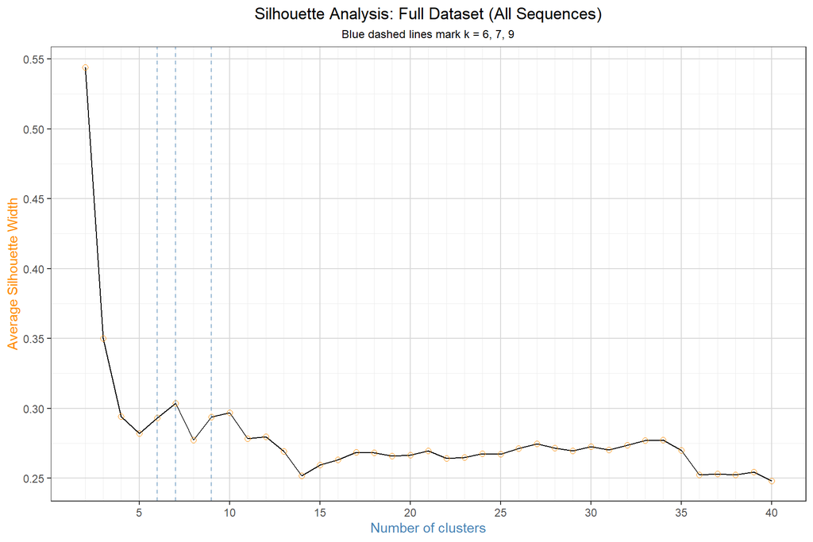

```r
future::plan(future::multisession, workers = N_WORKERS)

sil_width_full <- c(NA, future_sapply(2:K_MAX, function(k) {
  pam(gower_dist_full, diss = TRUE, k = k)$silinfo$avg.width
}))

future::plan(future::sequential)

sil_df_full <- data.frame(k = seq_len(K_MAX), width = sil_width_full)
sil_df_full <- sil_df_full[!is.na(sil_df_full$width), ]

ggplot(sil_df_full, aes(x = k, y = width)) +
  geom_line(colour = "black") +
  geom_point(colour = "darkorange", shape = 1, size = 2) +
  geom_vline(xintercept = c(6L, 7L, 9L), linetype = "dashed", colour = "steelblue", alpha = 0.6) +
  scale_x_continuous(limits = c(2L, K_MAX),
                     breaks = seq(5, K_MAX, by = 5),
                     minor_breaks = seq(2, K_MAX, by = 1)) +
  scale_y_continuous(breaks = scales::pretty_breaks(n = 6)) +
  labs(title    = "Silhouette Analysis: Full Dataset (All Sequences)",
       subtitle = "Blue dashed lines mark k = 6, 7, 9",
       x = "Number of clusters", y = "Average Silhouette Width") +
  theme_bw() +
  theme(panel.grid.major  = element_line(colour = "grey85"),
        panel.grid.minor  = element_line(colour = "grey93"),
        plot.title        = element_text(hjust = 0.5),
        plot.subtitle     = element_text(hjust = 0.5, size = 9),
        axis.title.x      = element_text(colour = "steelblue"),
        axis.title.y      = element_text(colour = "darkorange"))
```

```r
optimal_k_full <- which.max(sil_width_full)
cat(sprintf("Optimal k by silhouette (full dataset): %d  (width = %.4f)\n",
            optimal_k_full, max(sil_width_full, na.rm = TRUE)))
```

```
#> Optimal k by silhouette (full dataset): 2  (width = 0.5439)
```

## 13.4 PAM Fitting

```r
K_HIGHLIGHT_FULL <- c(6L, 7L, 9L)

pam_fits_full <- lapply(K_HIGHLIGHT_FULL, function(k)
  pam(gower_dist_full, diss = TRUE, k = k))
names(pam_fits_full) <- paste0("k", K_HIGHLIGHT_FULL)

for (k in K_HIGHLIGHT_FULL) {
  cat(sprintf("k=%d cluster sizes: ", k))
  cat(paste(table(pam_fits_full[[paste0("k",k)]]$clustering), collapse=" | "), "\n")
}
```

```
#> k=6 cluster sizes: 321 | 150 | 65 | 73 | 41 | 68
#> k=7 cluster sizes: 385 | 65 | 76 | 35 | 46 | 42 | 69
#> k=9 cluster sizes: 309 | 70 | 63 | 67 | 35 | 43 | 41 | 69 | 21
```

## 13.5 t-SNE Visualisation

```r
set.seed(TSNE_SEED)
tsne_full_obj <- Rtsne(gower_dist_full, is_distance = TRUE,
                       perplexity = TSNE_PERPLEXITY)

tsne_full_base <- as.data.frame(tsne_full_obj$Y) |>
  setNames(c("X", "Y"))
```

```r
# Integer matrix for medoid decoding and VOC matching (built once, reused)
AL_full_int     <- AL_full_fac_uniq |>
  mutate_if(is.factor, function(x) as.integer(as.character(x)))
AL_full_int_mat <- as.matrix(AL_full_int)

# VOC list for full dataset (Alpha, Beta, Delta, Gamma only)
voc_list_full <- list(
  Delta = get_variant_snps("Delta"),
  Alpha = get_variant_snps("Alpha"),
  Beta  = get_variant_snps("Beta"),
  Gamma = get_variant_snps("Gamma")
)

# Fixed axis ranges for identical plot area across all k values
x_pad_f    <- diff(range(tsne_full_base$X)) * 0.05
y_pad_f    <- diff(range(tsne_full_base$Y)) * 0.05
xlim_fix_f <- range(tsne_full_base$X) + c(-x_pad_f,  x_pad_f)
ylim_fix_f <- range(tsne_full_base$Y) + c(-y_pad_f,  y_pad_f)
```

```r
for (k in K_HIGHLIGHT_FULL) {
  fit_f      <- pam_fits_full[[paste0("k", k)]]
  med_f      <- fit_f$id.med
  cl_sizes_f <- as.integer(table(fit_f$clustering))

  # ── t-SNE plot ─────────────────────────────────────────────────────────────
  cat(sprintf("\n## Full Dataset PAM k = %d\n\n### t-SNE Plot\n\n", k))

  df_f <- tsne_full_base |>
    mutate(cluster   = factor(fit_f$clustering),
           is_medoid = row_number() %in% med_f)

  p_f <- ggplot(df_f, aes(x = X, y = Y, colour = cluster, shape = cluster)) +
    geom_point(size = 1.5, alpha = 0.5) +
    scale_shape_manual(values = seq(0, k)) +
    geom_point(data        = subset(df_f, is_medoid),
               aes(x = X, y = Y),
               colour      = "red", shape = 18, size = 5, alpha = 0.45,
               inherit.aes = FALSE) +
    coord_cartesian(xlim = xlim_fix_f, ylim = ylim_fix_f) +
    labs(title    = sprintf("PAM k = %d | Full Dataset t-SNE", k),
         subtitle = sprintf("Unique sequences: %d | Red diamonds = cluster medoids",
                            nrow(AL_full_fac_uniq)),
         x = "t-SNE dimension 1", y = "t-SNE dimension 2") +
    theme_bw() +
    theme(plot.title    = element_text(hjust = 0.5),
          plot.subtitle = element_text(hjust = 0.5, size = 9))
  print(p_f)

  # ── Medoid sequences table ──────────────────────────────────────────────────
  cat(sprintf("\n### Medoid Sequences (k = %d)\n\n", k))

  med_aa <- decode_aa_sequence(as.matrix(AL_full_int[med_f, , drop = FALSE]))
  med_df <- as.data.frame(med_aa)
  colnames(med_df) <- as.character(selected_sites_full)
  rownames(med_df) <- paste0("cl_", seq_len(k))
  med_df <- cbind(N = cl_sizes_f, med_df)

  if (k > 1L) {
    for (ri in 2L:k) {
      for (nm in as.character(selected_sites_full)) {
        v1 <- med_df[1L, nm]; vi <- med_df[ri, nm]
        if (!is.na(vi) && vi != v1)
          med_df[ri, nm] <- cell_spec(vi, format = "html", color = "red", bold = TRUE)
      }
    }
  }
  kt(
    kbl(med_df, format = "html", escape = FALSE,
        caption = sprintf(
          "Medoid sequences (k=%d, full dataset) | N = cluster size | red = differs from cl_1",
          k)) |>
      kable_styling(bootstrap_options = c("condensed","hover"),
                    font_size = 11, full_width = FALSE) |>
      row_spec(1L, background = "#d6eaf8")
  )

  # ── VOC SNP content table ───────────────────────────────────────────────────
  cat(sprintf("\n### VOC SNP Content (k = %d)\n\n", k))

  voc_tbl_f <- do.call(rbind, lapply(seq_len(k), function(cl_i) {
    row_i <- med_f[cl_i]
    vapply(names(voc_list_full), function(voc_nm) {
      voc  <- voc_list_full[[voc_nm]]
      n_ov <- length(intersect(as.character(voc$sites),
                               as.character(selected_sites_full)))
      n_m  <- count_snp_matches(AL_full_int_mat[row_i, ], voc)
      sprintf("%d / %d", n_m, n_ov)
    }, character(1L))
  }))
  voc_tbl_f           <- as.data.frame(voc_tbl_f)
  rownames(voc_tbl_f) <- paste0("cl_", seq_len(k))

  kt(
    kbl(voc_tbl_f, format = "html",
        caption = sprintf(
          "VOC SNP matches per medoid (matched / overlap sites), full dataset k=%d",
          k)) |>
      kable_styling(bootstrap_options = c("condensed","hover"),
                    font_size = 11, full_width = FALSE)
  )
  cat("\n")
}
```

## 13.6 Full Dataset PAM k = 6

### 13.6.1 t-SNE Plot

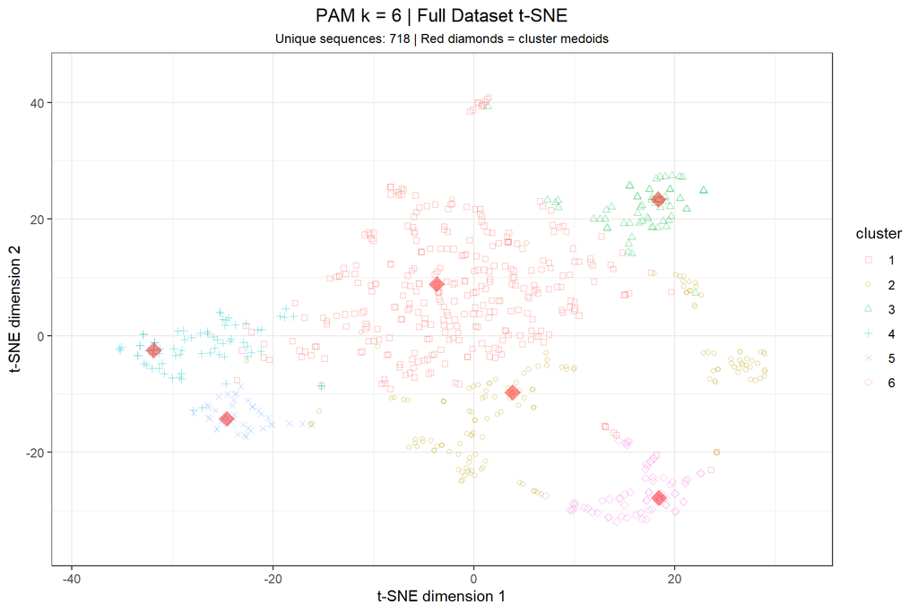

### Medoid Sequences (k = 6)

Medoid sequences (k=6, full dataset) | N = cluster size | red = differs from cl_1

|  | N | 5 | 13 | 18 | 20 | 26 | 95 | 138 | 152 | 190 | 253 | 417 | 452 | 477 | 478 | 484 | 494 | 501 | 614 | 655 | 677 | 681 | 688 | 701 | 716 | 732 | 769 | 957 | 1027 | … |
| --- | --- | --- | --- | --- | --- | --- | --- | --- | --- | --- | --- | --- | --- | --- | --- | --- | --- | --- | --- | --- | --- | --- | --- | --- | --- | --- | --- | --- | --- | --- |
| cl_1 | 321 | L | S | L | T | P | T | D | W | R | D | K | L | S | T | E | S | N | G | H | Q | P | A | A | T | T | G | Q | T | … |
| cl_2 | 150 | L | S | L | T | P | T | D | W | R | D | K | L | S | T | E | S | N | G | H | Q | H | A | A | T | T | G | Q | T | … |
| cl_3 | 65 | L | I | L | T | P | T | D | C | R | D | K | R | S | T | E | S | N | G | H | Q | P | A | A | T | T | G | Q | T | … |
| cl_4 | 73 | F | S | L | T | P | I | D | W | R | G | K | L | S | T | K | S | N | G | H | Q | P | A | V | T | T | G | Q | T | … |
| cl_5 | 41 | F | S | L | T | P | I | D | W | R | G | K | L | N | T | E | S | N | G | H | Q | P | A | A | T | T | G | R | T | … |
| cl_6 | 68 | L | S | F | N | S | T | Y | W | S | D | T | L | S | T | K | S | Y | G | Y | Q | P | A | A | T | T | G | Q | I | … |

### 13.6.2 VOC SNP Content (k = 6)

VOC SNP matches per medoid (matched / overlap sites), full dataset k=6

|  | Delta | Alpha | Beta | Gamma |
| --- | --- | --- | --- | --- |
| cl_1 | 0 / 3 | 0 / 3 | 0 / 4 | 0 / 10 |
| cl_2 | 0 / 3 | 1 / 3 | 0 / 4 | 0 / 10 |
| cl_3 | 1 / 3 | 0 / 3 | 0 / 4 | 0 / 10 |
| cl_4 | 0 / 3 | 0 / 3 | 2 / 4 | 1 / 10 |
| cl_5 | 0 / 3 | 0 / 3 | 0 / 4 | 0 / 10 |
| cl_6 | 0 / 3 | 1 / 3 | 2 / 4 | 10 / 10 |

## 13.7 Full Dataset PAM k = 7

### 13.7.1 t-SNE Plot

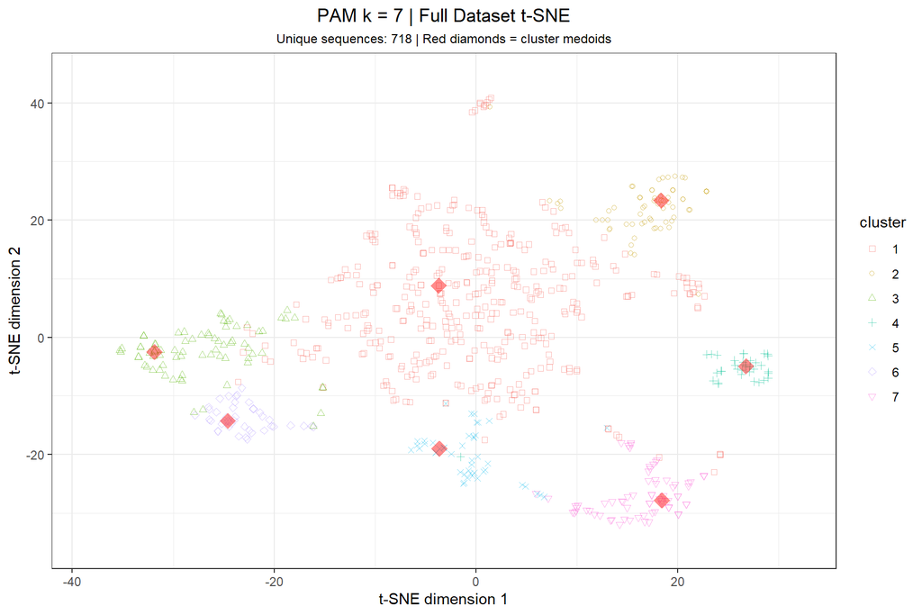

### Medoid Sequences (k = 7)

Medoid sequences (k=7, full dataset) | N = cluster size | red = differs from cl_1

|  | N | 5 | 13 | 18 | 20 | 26 | 95 | 138 | 152 | 190 | 253 | 417 | 452 | 477 | 478 | 484 | 494 | 501 | 614 | 655 | 677 | 681 | 688 | 701 | 716 | 732 | 769 | 957 | 1027 | … |
| --- | --- | --- | --- | --- | --- | --- | --- | --- | --- | --- | --- | --- | --- | --- | --- | --- | --- | --- | --- | --- | --- | --- | --- | --- | --- | --- | --- | --- | --- | --- |
| cl_1 | 385 | L | S | L | T | P | T | D | W | R | D | K | L | S | T | E | S | N | G | H | Q | P | A | A | T | T | G | Q | T | … |
| cl_2 | 65 | L | I | L | T | P | T | D | C | R | D | K | R | S | T | E | S | N | G | H | Q | P | A | A | T | T | G | Q | T | … |
| cl_3 | 76 | F | S | L | T | P | I | D | W | R | G | K | L | S | T | K | S | N | G | H | Q | P | A | V | T | T | G | Q | T | … |
| cl_4 | 35 | L | S | L | T | P | T | D | W | R | D | K | L | S | K | E | S | N | G | H | Q | H | A | A | T | A | G | Q | T | … |
| cl_5 | 46 | L | S | L | T | P | T | D | W | R | D | K | L | S | T | E | S | Y | G | H | Q | H | A | A | I | T | G | Q | T | … |
| cl_6 | 42 | F | S | L | T | P | I | D | W | R | G | K | L | N | T | E | S | N | G | H | Q | P | A | A | T | T | G | R | T | … |
| cl_7 | 69 | L | S | F | N | S | T | Y | W | S | D | T | L | S | T | K | S | Y | G | Y | Q | P | A | A | T | T | G | Q | I | … |

### 13.7.2 VOC SNP Content (k = 7)

VOC SNP matches per medoid (matched / overlap sites), full dataset k=7

|  | Delta | Alpha | Beta | Gamma |
| --- | --- | --- | --- | --- |
| cl_1 | 0 / 3 | 0 / 3 | 0 / 4 | 0 / 10 |
| cl_2 | 1 / 3 | 0 / 3 | 0 / 4 | 0 / 10 |
| cl_3 | 0 / 3 | 0 / 3 | 2 / 4 | 1 / 10 |
| cl_4 | 1 / 3 | 1 / 3 | 0 / 4 | 0 / 10 |
| cl_5 | 0 / 3 | 3 / 3 | 1 / 4 | 1 / 10 |
| cl_6 | 0 / 3 | 0 / 3 | 0 / 4 | 0 / 10 |
| cl_7 | 0 / 3 | 1 / 3 | 2 / 4 | 10 / 10 |

## 13.8 Full Dataset PAM k = 9

### 13.8.1 t-SNE Plot

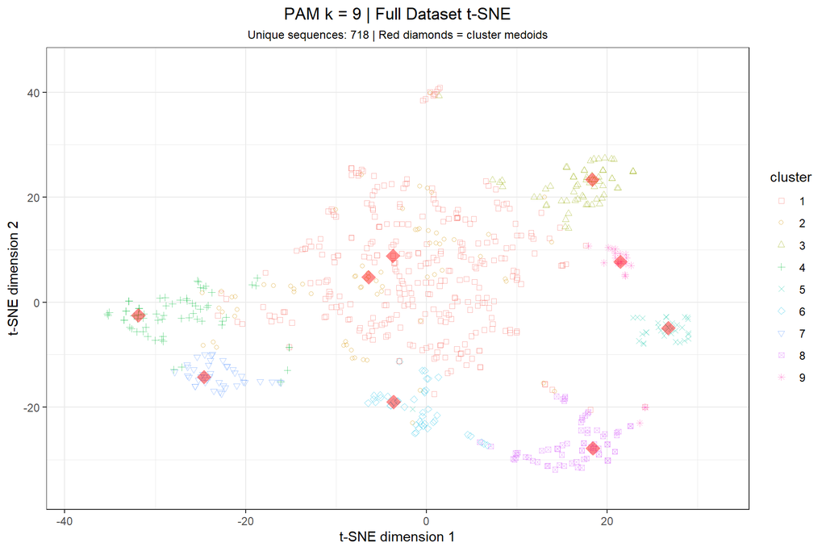

### Medoid Sequences (k = 9)

Medoid sequences (k=9, full dataset) | N = cluster size | red = differs from cl_1

|  | N | 5 | 13 | 18 | 20 | 26 | 95 | 138 | 152 | 190 | 253 | 417 | 452 | 477 | 478 | 484 | 494 | 501 | 614 | 655 | 677 | 681 | 688 | 701 | 716 | 732 | 769 | 957 | 1027 | … |
| --- | --- | --- | --- | --- | --- | --- | --- | --- | --- | --- | --- | --- | --- | --- | --- | --- | --- | --- | --- | --- | --- | --- | --- | --- | --- | --- | --- | --- | --- | --- |
| cl_1 | 309 | L | S | L | T | P | T | D | W | R | D | K | L | S | T | E | S | N | G | H | Q | P | A | A | T | T | G | Q | T | … |
| cl_2 | 70 | F | S | L | T | P | T | D | W | R | D | K | L | S | T | E | S | N | G | H | Q | P | A | A | T | T | G | Q | T | … |
| cl_3 | 63 | L | I | L | T | P | T | D | C | R | D | K | R | S | T | E | S | N | G | H | Q | P | A | A | T | T | G | Q | T | … |
| cl_4 | 67 | F | S | L | T | P | I | D | W | R | G | K | L | S | T | K | S | N | G | H | Q | P | A | V | T | T | G | Q | T | … |
| cl_5 | 35 | L | S | L | T | P | T | D | W | R | D | K | L | S | K | E | S | N | G | H | Q | H | A | A | T | A | G | Q | T | … |
| cl_6 | 43 | L | S | L | T | P | T | D | W | R | D | K | L | S | T | E | S | Y | G | H | Q | H | A | A | I | T | G | Q | T | … |
| cl_7 | 41 | F | S | L | T | P | I | D | W | R | G | K | L | N | T | E | S | N | G | H | Q | P | A | A | T | T | G | R | T | … |
| cl_8 | 69 | L | S | F | N | S | T | Y | W | S | D | T | L | S | T | K | S | Y | G | Y | Q | P | A | A | T | T | G | Q | I | … |
| cl_9 | 21 | L | S | L | T | P | T | D | W | R | D | K | R | S | K | E | S | N | G | H | Q | R | A | A | T | T | G | Q | T | … |

### 13.8.2 VOC SNP Content (k = 9)

VOC SNP matches per medoid (matched / overlap sites), full dataset k=9

|  | Delta | Alpha | Beta | Gamma |
| --- | --- | --- | --- | --- |
| cl_1 | 0 / 3 | 0 / 3 | 0 / 4 | 0 / 10 |
| cl_2 | 0 / 3 | 0 / 3 | 0 / 4 | 0 / 10 |
| cl_3 | 1 / 3 | 0 / 3 | 0 / 4 | 0 / 10 |
| cl_4 | 0 / 3 | 0 / 3 | 2 / 4 | 1 / 10 |
| cl_5 | 1 / 3 | 1 / 3 | 0 / 4 | 0 / 10 |
| cl_6 | 0 / 3 | 3 / 3 | 1 / 4 | 1 / 10 |
| cl_7 | 0 / 3 | 0 / 3 | 0 / 4 | 0 / 10 |
| cl_8 | 0 / 3 | 1 / 3 | 2 / 4 | 10 / 10 |
| cl_9 | 3 / 3 | 0 / 3 | 0 / 4 | 0 / 10 |

# 14 Summary (Clustering Accuracy)

```r
cat("== Analysis Summary ==\n\n")
```

```
#> == Analysis Summary ==
```

```r
cat(sprintf("Country filter:         %s\n",
            ifelse(is.null(COUNTRY), "none (all countries)", COUNTRY)))
```

```
#> Country filter:         USA
```

```r
cat(sprintf("Unique sequences:       %s\n", UNIQUE_SEQS))
```

```
#> Unique sequences:       TRUE
```

```r
cat(sprintf("Period 1 sequences:     %d  (%s to %s)\n",
            n_p1_eff, PERIOD1_START, PERIOD1_END))
```

```
#> Period 1 sequences:     36  (2020-05-01 to 2020-07-01)
```

```r
cat(sprintf("Period 2 sequences:     %d  (%s to %s)\n",
            n_p2_eff, PERIOD2_START, PERIOD2_END))
```

```
#> Period 2 sequences:     91  (2021-07-01 to 2021-09-01)
```

```r
cat(sprintf("GMM-selected sites:     %d  [%s]\n",
            length(selected_sites),
            paste(selected_sites, collapse = ", ")))
```

```
#> GMM-selected sites:     34  [5, 18, 19, 20, 26, 54, 95, 138, 141, 142, 144, 152, 153, 155, 157, 158, 180, 183, 190, 253, 417, 452, 477, 478, 484, 501, 520, 614, 655, 681, 701, 950, 1027, 1176]
```

```r
cat("\nVOC SNP overlap with GMM-selected sites:\n")
```

```
#>
#> VOC SNP overlap with GMM-selected sites:
```

```r
for (nm in names(overlap_list)) {
  ov <- overlap_list[[nm]]
  cat(sprintf("  %-6s: %s\n",
              nm,
              if (length(ov) > 0) paste(ov, collapse = ", ") else "none"))
}
```

```
#>   Delta : 19, 452, 478, 681, 950
#>   Alpha : 501, 681
#>   Beta  : 417, 484, 501, 701
#>   Gamma : 18, 20, 26, 138, 190, 417, 484, 501, 655, 1027
```

```r
cat(sprintf("\nOptimal k by silhouette:   %d\n", optimal_k))
```

```
#>
#> Optimal k by silhouette:   2
```

```r
cat(sprintf("Optimal k by F1 score:     %d\n\n",
            K_HIGHLIGHT[which.max(metrics_df$f1)]))
```

```
#> Optimal k by F1 score:     9
```

```r
cat("Classification metrics (k = 2, 3, 4, 9):\n")
```

```
#> Classification metrics (k = 2, 3, 4, 9):
```

```r
print(metrics_df[, c("k", "positive_cluster", "TP", "FP", "FN",
                      "precision", "recall", "f1")])
```

```
#>   k positive_cluster TP FP FN precision recall     f1
#> 1 2                1 36 64  0    0.3600      1 0.5294
#> 2 3                1 36 38  0    0.4865      1 0.6545
#> 3 4                1 36 34  0    0.5143      1 0.6792
#> 4 9                1 36 12  0    0.7500      1 0.8571
```

# 15 Conclusions

## 15.1 Clustering Accuracy Study (Steps 1–8)

`ViralEntropR`’s entropy-driven dimensionality reduction, combined with PAM clustering on Gower distance, recovers the temporal structure of SARS-CoV-2 evolution without any supervised learning or prior knowledge of mutation topology.

**Perfect recall across all solutions.** All PAM solutions (k = 2, 3 and 4) achieve recall = 1.00: every wild-type sequence (Period 1, May–June 2020) is assigned to the wild-type cluster. No ancestral sequence is assigned to the Delta-dominant partition despite the method being entirely unsupervised.

**F1 score peaks at k = 9, consistent with known biology.** While k = 2 achieves the highest silhouette width, k = 9 yields the best classification performance and is the biologically justified solution. During the combined surveillance window, the United States was host not only to the ancestral wild-type and the four designated VOCs (Alpha, Beta, Gamma and Delta) but also to several co-circulating Variants of Interest — Kappa, Iota, Epsilon and Lambda — each carrying distinct subsets of Spike mutations. The pairwise contrast analysis in Step 7 recovers mutation signatures consistent with several of these lineages, suggesting that the nine-cluster solution captures genuine sub-variant structure.

**The method is purely information-theoretic.** No feature engineering beyond Shannon entropy scoring is applied, and the spatial topology of sites along the Spike protein is entirely ignored. Sites are selected because their amino acid distribution changed between surveillance periods — as Shannon’s foundational framework predicts, entropy naturally captures the informative positions (Shannon 1948).

**Mode equals medoid: cluster cohesion confirmed.** For k = 2, 3 and 4, the modal amino acid at every selected site within each cluster matches the PAM medoid sequence exactly, confirming that these clusters are not statistical artefacts but reflect genuine population bottlenecks imposed by emergent variants. At k = 9, a small number of sites show minor discrepancies between the mode and the medoid, as expected when clusters become smaller and the within-cluster frequency distribution at some positions is more diffuse. Critically, these discrepancies do not alter the VOC SNP classification of any medoid: the defining mutation signatures remain intact, and the affected sites carry non-defining substitutions that do not change the lineage assignment.

**Unsupervised recovery of functionally annotated sites.** Steps 7 and 8 used no biological annotation. Yet the analysis independently flagged the NTD allosteric control node near residue 190 (Wrobel, Benton, and Bhatt 2020) and the antigenic supersite spanning positions 141–158 (McCallum et al. 2021; Liu et al. 2022) — both implicated in immune evasion and RBD conformational regulation. This convergence with independently established structural biology validates that the entropy pipeline captures genuine evolutionary signal.

## 15.2 Full-Dataset Clustering: Global Separation Patterns (Step 9)

The full-dataset analysis (Step 9) is conceptually distinct from the accuracy study. It operates on all ~109,536 available USA sequences across the full surveillance timeline, with GMM site selection (`selected_sites_full`) performed on the entire dataset. The selected sites therefore reflect population-wide entropy rather than the contrast between two specific windows, and the two site sets are expected to differ — this is by design. Prior to Gower distance computation and PAM clustering, sequences are deduplicated and only unique haplotypes are retained. This step is computationally necessary: the full 109,536-sequence distance matrix would require approximately 48 GB of RAM, which exceeds the capacity of a typical workstation. Deduplication reduces the working set to a tractable number of unique sequences while preserving the full haplotype diversity of the dataset, since PAM medoids and t-SNE coordinates are determined by sequence identity rather than sequence count.

`ViralEntropR` provides a transparent, reproducible, and computationally efficient framework for detecting and characterizing viral variant structure in large sequence datasets, combining rigorous information theory with the interpretability required for epidemiological application.The results confirm that Shannon entropy, computed without any prior biological annotation, is sufficient to select a compact site subset that recovers known variant structure at both the two-period and full-dataset scales.

# References

Brookes, Anthony J. 1999. “The Essence of SNPs.” *Gene* 234 (2): 177–86. https://doi.org/10.1016/S0378-1119(99)00219-X.

CDC COVID-19 Response Team. 2022. “Genomic Surveillance for SARS-CoV-2 Variants: Predominance of the Delta (b.1.617.2) and Omicron (b.1.1.529) Variants — United States, June 2021–January 2022.” *MMWR Morbidity and Mortality Weekly Report* 71 (6): 206–11. https://doi.org/10.15585/mmwr.mm7106e1.

Gower, John C. 1971. “A General Coefficient of Similarity and Some of Its Properties.” *Biometrics* 27 (4): 857–71. https://doi.org/10.2307/2528823.

Hartl, Daniel L., and Andrew G. Clark. 2007. *Principles of Population Genetics*. 4th ed. Sinauer Associates.

Johnson, Bryan A., Xuping Xie, and Vineet D. Menachery. 2021. “Loss of Furin Cleavage Site Attenuates SARS-CoV-2 Pathogenesis.” *Nature* 591 (7849): 293–99. https://doi.org/10.1038/s41586-021-03237-4.

Kaufman, Leonard, and Peter J. Rousseeuw. 1990. *Finding Groups in Data: An Introduction to Cluster Analysis*. Wiley. https://doi.org/10.1002/9780470316801.

Korber, Bette, Will M. Fischer, and Sandrasegaram Gnanakaran. 2020. “Tracking Changes in SARS-CoV-2 Spike: Evidence That D614G Increases Infectivity of the COVID-19 Virus.” *Cell* 182 (4): 812–827.e19. https://doi.org/10.1016/j.cell.2020.06.043.

Liu, Lihong, Sho Iketani, Yicheng Guo, and David D. Ho. 2022. “Striking Antibody Evasion Manifested by the Omicron Variant of SARS-CoV-2.” *Nature* 602: 676–81. https://doi.org/10.1038/s41586-021-04388-0.

Maaten, Laurens van der, and Geoffrey Hinton. 2008. “Visualizing Data Using t-SNE.” *Journal of Machine Learning Research* 9: 2579–2605. http://jmlr.org/papers/v9/vandermaaten08a.html.

McCallum, Matthew, Anna De Marco, Alexandra C. Walls, and David Veesler. 2021. “N-Terminal Domain Antigenic Mapping Reveals a Site of Vulnerability for SARS-CoV-2.” *Cell* 184 (9): 2332–2347.e2. https://doi.org/10.1016/j.cell.2021.03.028.

Peacock, Thomas P., Daniel H. Goldhill, Jie Zhou, Laury Baillon, Rebecca Frise, Olivia C. Swann, Raveen Kugathasan, et al. 2021. “The Furin Cleavage Site in the SARS-CoV-2 Spike Protein Is Required for Transmission in Ferrets.” *Nature Microbiology* 6 (7): 899–909. https://doi.org/10.1038/s41564-021-00908-w.

Rousseeuw, Peter J. 1987. “Silhouettes: A Graphical Aid to the Interpretation and Validation of Cluster Analysis.” *Journal of Computational and Applied Mathematics* 20: 53–65. https://doi.org/10.1016/0377-0427(87)90125-7.

Shannon, Claude E. 1948. “A Mathematical Theory of Communication.” *Bell System Technical Journal* 27 (3): 379–423. https://doi.org/10.1002/j.1538-7305.1948.tb01338.x.

World Health Organization. 2023. “Historical Working Definitions and Primary Actions for SARS-CoV-2 Variants.” https://www.who.int/publications/m/item/historical-working-definitions-and-primary-actions-for-sars-cov-2-variants.

Wrobel, Antoni G., Donald J. Benton, and Saket Bhatt. 2020. “SARS-CoV-2 and Bat RaTG13 Spike Glycoprotein Structures Inform on Virus Evolution and Furin-Cleavage Effects.” *Nature Structural & Molecular Biology* 27: 763–67. https://doi.org/10.1038/s41594-020-0468-7.